# mpl_toolkits.mplot3d.axes3d.Axes3D.plot_surface

**Axes3D.plot_surface(*X*, *Y*, *Z*, *, *norm=None*, *vmin=None*, *vmax=None*, *lightsource=None*, *axlim_clip=False*, **kwargs)[[source]](https://github.com/matplotlib/matplotlib/blob/v3.10.8/lib/mpl_toolkits/mplot3d/axes3d.py#L2125-L2322)**

Create a surface plot.

By default, it will be colored in shades of a solid color, but it also supports colormapping by supplying the *cmap* argument.

Note

The *rcount* and *ccount* kwargs, which both default to 50, determine the maximum number of samples used in each direction. If the input data is larger, it will be downsampled (by slicing) to these numbers of points.

Note

To maximize rendering speed consider setting *rstride* and *cstride* to divisors of the number of rows minus 1 and columns minus 1 respectively. For example, given 51 rows rstride can be any of the divisors of 50.

Similarly, a setting of *rstride* and *cstride* equal to 1 (or *rcount* and *ccount* equal the number of rows and columns) can use the optimized path.

**Parameters:**

**X, Y, Z**2D arrays**

Data values.

**rcount, ccount**int**

Maximum number of samples used in each direction. If the input data is larger, it will be downsampled (by slicing) to these numbers of points. Defaults to 50.

**rstride, cstride**int**

Downsampling stride in each direction. These arguments are mutually exclusive with *rcount* and *ccount*. If only one of *rstride* or *cstride* is set, the other defaults to 10.

'classic' mode uses a default of `rstride = cstride = 10` instead of the new default of `rcount = ccount = 50`.

**color**[color](https://matplotlib.org/stable/users/explain/colors/colors.html#colors-def)**

Color of the surface patches.

**cmap**Colormap, optional**

Colormap of the surface patches.

**facecolors**list of [color](https://matplotlib.org/stable/users/explain/colors/colors.html#colors-def)**

Colors of each individual patch.

**norm**`Normalize`, optional**

Normalization for the colormap.

**vmin, vmax**float, optional**

Bounds for the normalization.

**shade**bool, default: True**

Whether to shade the facecolors. Shading is always disabled when *cmap* is specified.

**lightsource**`LightSource`, optional**

The lightsource to use when *shade* is True.

**axlim_clip**bool, default: False**

Whether to hide patches with a vertex outside the axes view limits.

Added in version 3.10.

**kwargs**

Other keyword arguments are forwarded to `Poly3DCollection`.

## Examples using `mpl_toolkits.mplot3d.axes3d.Axes3D.plot_surface`

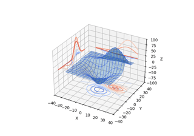

[Project contour profiles onto a graph](https://matplotlib.org/stable/gallery/mplot3d/contour3d_3.html)

Project contour profiles onto a graph

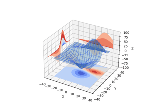

[Project filled contour onto a graph](https://matplotlib.org/stable/gallery/mplot3d/contourf3d_2.html)

Project filled contour onto a graph

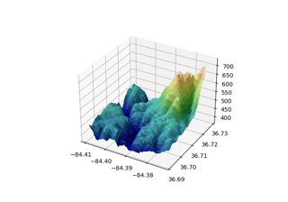

[Custom hillshading in a 3D surface plot](https://matplotlib.org/stable/gallery/mplot3d/custom_shaded_3d_surface.html)

Custom hillshading in a 3D surface plot

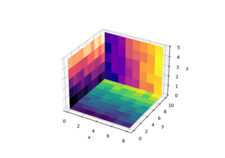

[2D images in 3D](https://matplotlib.org/stable/gallery/mplot3d/imshow3d.html)

2D images in 3D

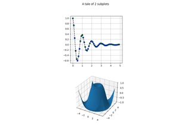

[2D and 3D Axes in same figure](https://matplotlib.org/stable/gallery/mplot3d/mixed_subplots.html)

2D and 3D Axes in same figure

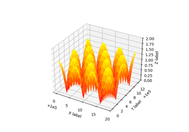

[Automatic text offsetting](https://matplotlib.org/stable/gallery/mplot3d/offset.html)

Automatic text offsetting

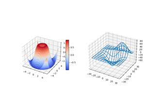

[3D plots as subplots](https://matplotlib.org/stable/gallery/mplot3d/subplot3d.html)

3D plots as subplots

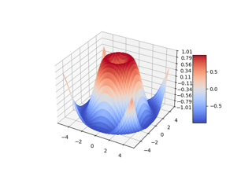

[3D surface (colormap)](https://matplotlib.org/stable/gallery/mplot3d/surface3d.html)

3D surface (colormap)

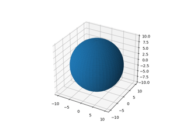

[3D surface (solid color)](https://matplotlib.org/stable/gallery/mplot3d/surface3d_2.html)

3D surface (solid color)

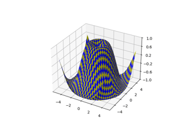

[3D surface (checkerboard)](https://matplotlib.org/stable/gallery/mplot3d/surface3d_3.html)

3D surface (checkerboard)

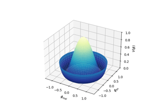

[3D surface with polar coordinates](https://matplotlib.org/stable/gallery/mplot3d/surface3d_radial.html)

3D surface with polar coordinates

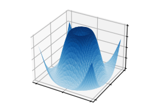

[plot_surface(X, Y, Z)](https://matplotlib.org/stable/plot_types/3D/surface3d_simple.html)

plot_surface(X, Y, Z)